# Loan ML

### The Data

#### Variables utilized in the Supervised Learning dataset

- Loan_Amnt::: The listed amount of the loan applied for by the borrower. If at some point in time, the credit # department reduces the loan amount, then it will be reflected in this value.
- funded_amnt:: The total amount committed to that loan at that point in time.
- funded_inv: The total amount committed by investors for that loan at that point in time.
- term: The number of payments on the loan. Values are in months and can be either 36 or 60.
- int_rate: Interest rate on the loan
- installment: The monhtly paymented owed by the borrower if the loan originates (when borrower is approved for the loan)
- grade: LendingClub assigned loan grade (associated with an interest rate, modeled return range, modeled default range, and origination fee. The loan grades range from “A”, which is the lowest modeled risk/return, to “G”, which is the highest modeled risk/return.)
- sub_grade: LendingClub assigned subgrade (incremental from A1 to G5)
- emp_length: Employment length in years. Possible values are between 0 and 10 where 0 means less than one year and 10 means ten or more years.
- home _ownership: The home ownership status provided by the borrower during registration. Value options: RENT, OWN, MORTGAGE, OTHER.
- annual_incom: The self-reported annual income provided by the borrower during registration.
- verification_status: Indicates if the co-borrowers’ joint income was verified by LendingClub, not verified, or if the income source was verified
- issue_d: The month which the loan was funded
- loan_status: Current status of the loan
- purpose: A category provided by the borrower for the loan request.
- addr_state: The state provided by the borrower in the loan application
- dti: (debt-to-income) A ratio calculated using the borrower’s total monthly debt payments on the total debt obligations, excluding mortgage and the requested LendingClub loan, divided by the borrower’s self-reported monthly income.
- earliest_line: The month the borrower’s earliest reported credit line was opened
- inq_l6mths: The number of inquiries in past 6 months (excluding auto and mortgage inquiries)
- mths_sincedelinq: The number of months since the borrower’s last delinquency.
- open_acc: The number of open credit lines in the borrower’s credit file.
- pub_rec: Number of derogatory public records
- revol_bal: Total credit revolving balance
- revol_util: Revolving line utilization rate, or the amount of credit the borrower is using relative to all available revolving credit.
- total_acc: The total number of credit lines currently in the borrower’s credit file
- CP: Whether the originated loan fell into the guidelines of LendingClub’s credit policy or not. Return options are 0 or 1.

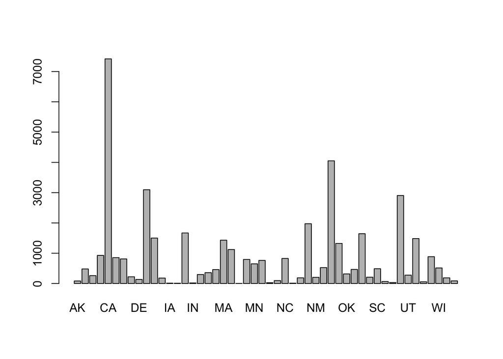

```
## data$addr_state
##       Frequency   Percent
## AK           84 1.981e-01
## AL          481 1.134e+00
## AR          260 6.131e-01
## AZ          928 2.188e+00
## CA         7418 1.749e+01
## CO          855 2.016e+00
## CT          812 1.915e+00
## DC          222 5.235e-01
## DE          135 3.184e-01
## FL         3097 7.303e+00
## GA         1501 3.540e+00
## HI          180 4.245e-01
## IA           12 2.830e-02
## ID            9 2.122e-02
## IL         1669 3.936e+00
## IN           19 4.480e-02
## KS          296 6.980e-01
## KY          358 8.442e-01
## LA          460 1.085e+00
## MA         1431 3.375e+00
## MD         1122 2.646e+00
## ME            3 7.074e-03
## MI          795 1.875e+00
## MN          650 1.533e+00
## MO          763 1.799e+00
## MS           26 6.131e-02
## MT           96 2.264e-01
## NC          827 1.950e+00
## NE           11 2.594e-02
## NH          188 4.433e-01
## NJ         1974 4.655e+00
## NM          204 4.811e-01
## NV          526 1.240e+00
## NY         4051 9.553e+00
## OH         1324 3.122e+00
## OK          317 7.475e-01
## OR          465 1.097e+00
## PA         1644 3.877e+00
## RI          208 4.905e-01
## SC          489 1.153e+00
## SD           66 1.556e-01
## TN           32 7.546e-02
## TX         2906 6.853e+00
## UT          277 6.532e-01
## VA         1484 3.500e+00
## VT           57 1.344e-01
## WA          886 2.089e+00
## WI          514 1.212e+00
## WV          187 4.410e-01
## WY           87 2.052e-01
## Total     42406 1.000e+02
```

```r
freq(data$addr_state)
```

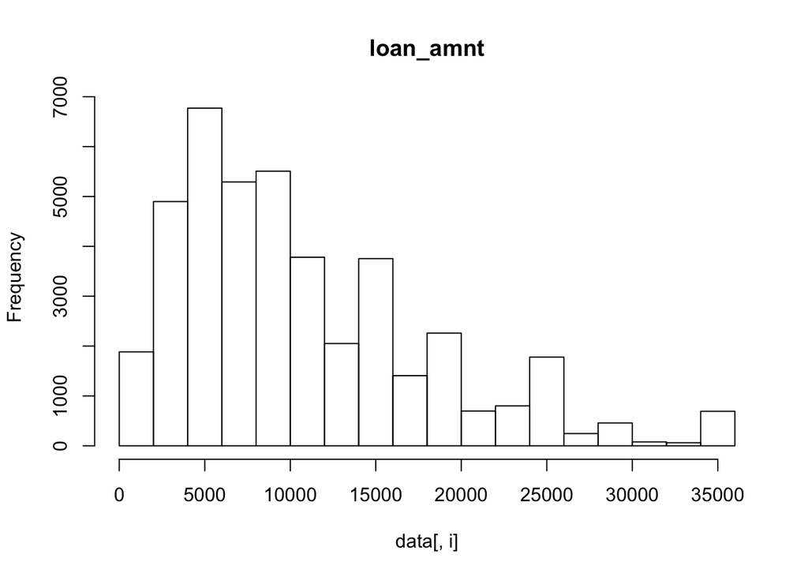

```
## [1] "hist(data[,1],main=\"loan_amnt\")"
```

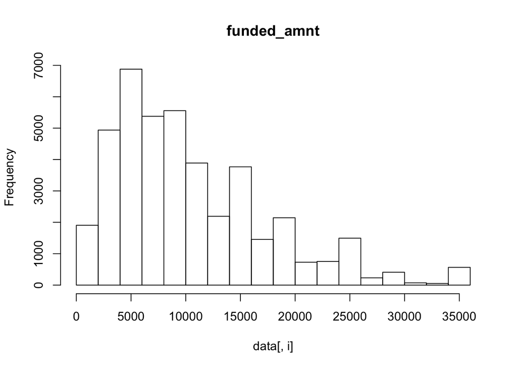

```
## [1] "hist(data[,2],main=\"funded_amnt\")"
```

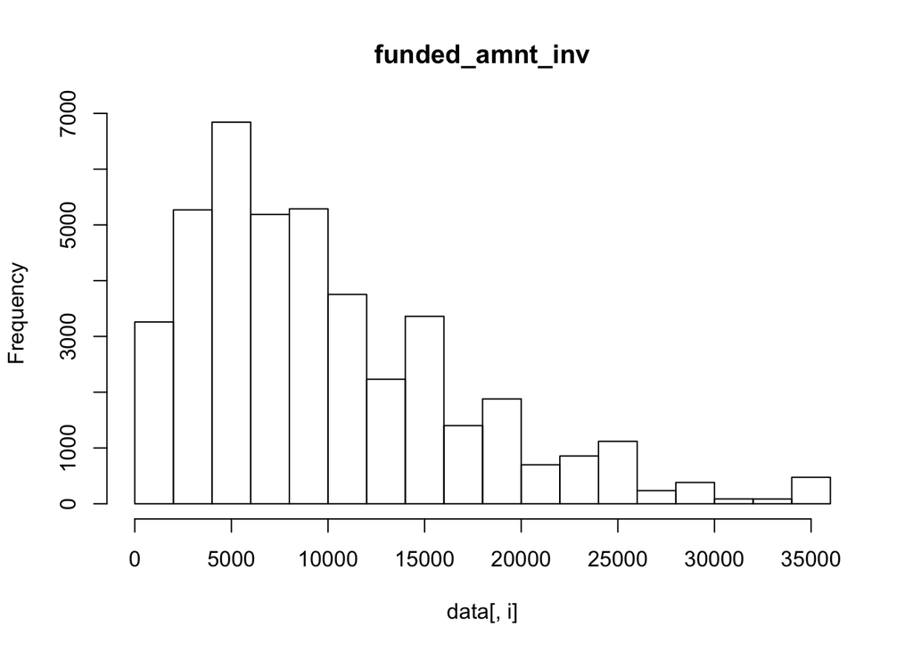

```
## [1] "hist(data[,3],main=\"funded_amnt_inv\")"
```

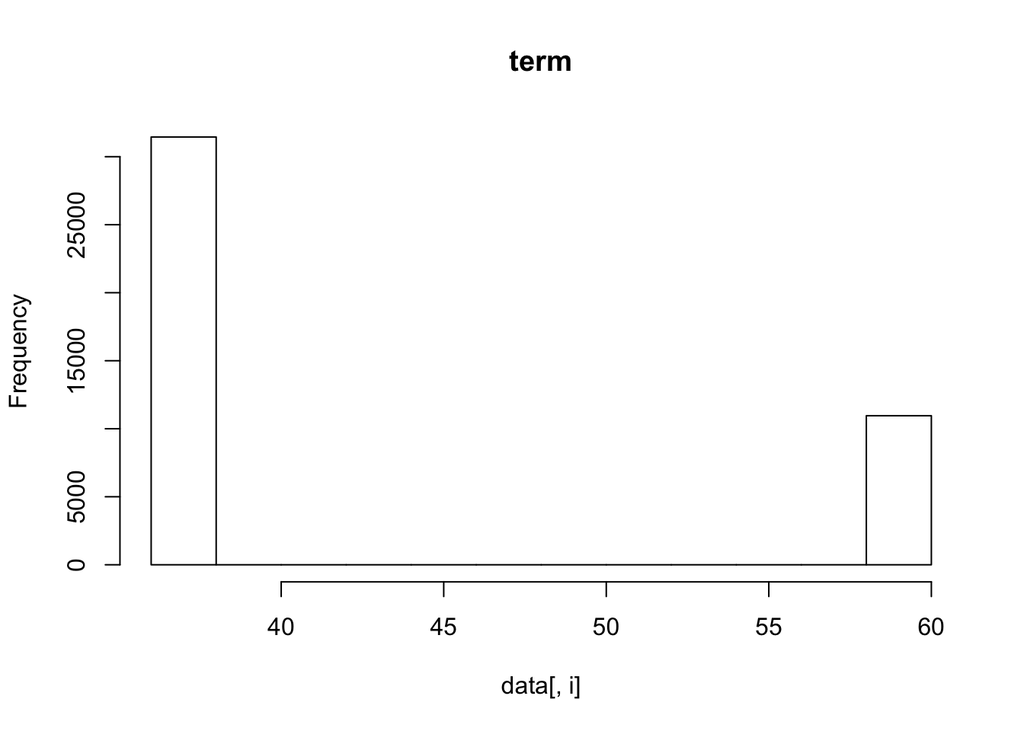

```
## [1] "hist(data[,4],main=\"term\")"
```

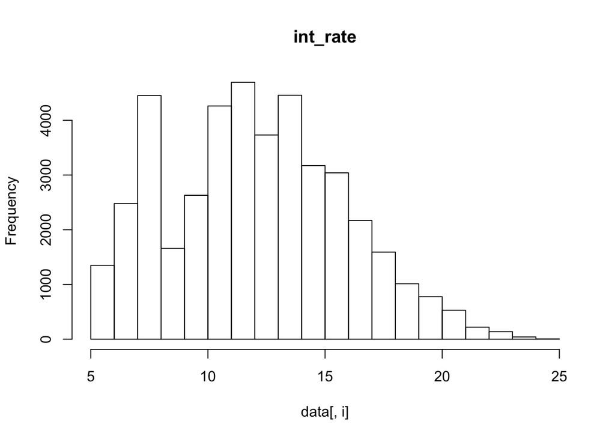

```
## [1] "hist(data[,5],main=\"int_rate\")"
```

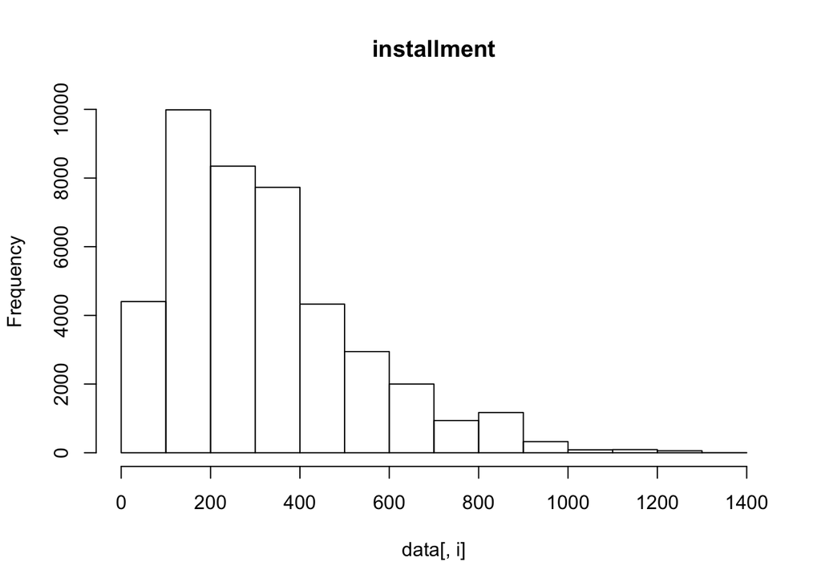

```
## [1] "hist(data[,6],main=\"installment\")"
```

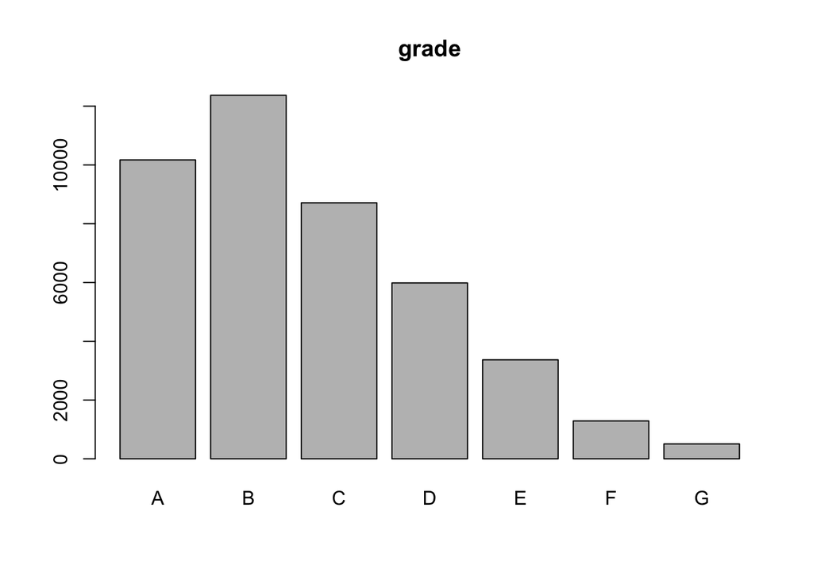

```
## [1] "freq(data[,7],main=\"grade\")"
```

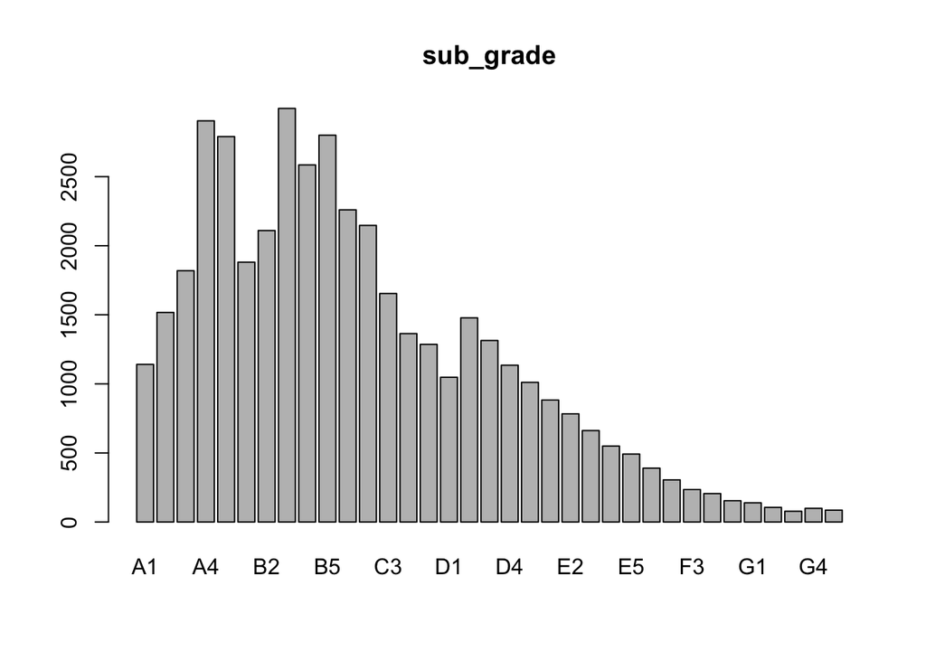

```
## [1] "freq(data[,8],main=\"sub_grade\")"
```

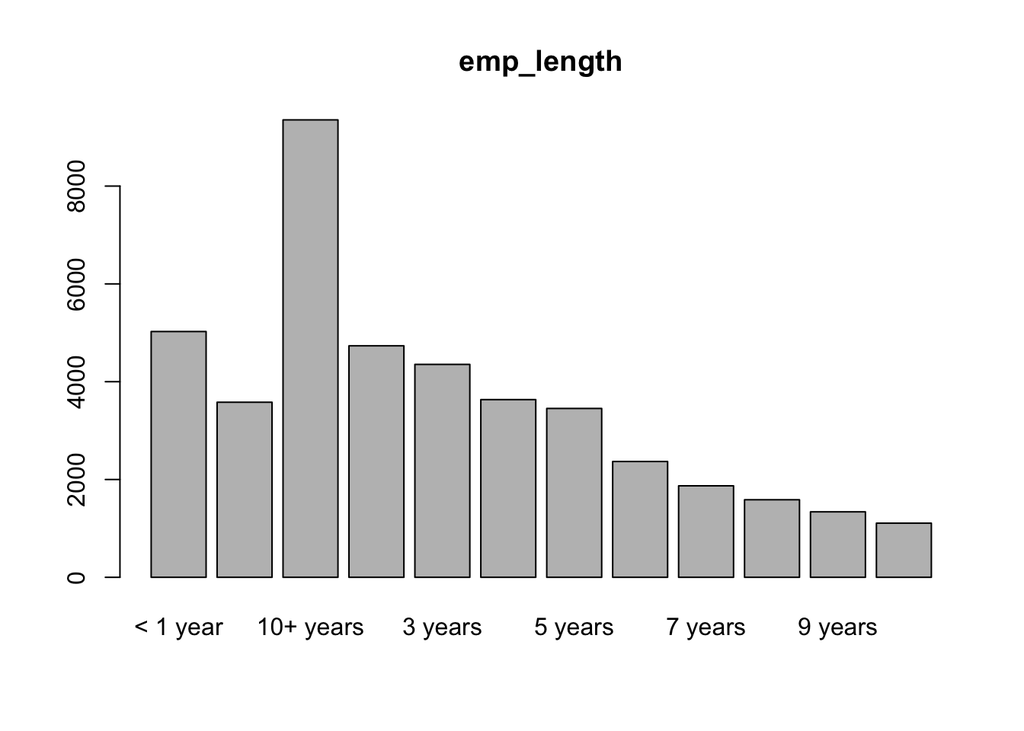

```
## [1] "freq(data[,9],main=\"emp_length\")"
```

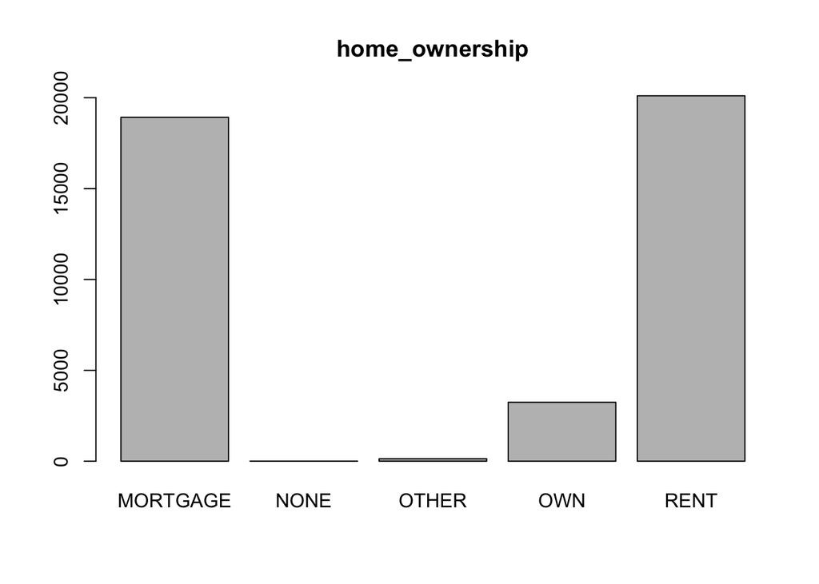

```
## [1] "freq(data[,10],main=\"home_ownership\")"
```

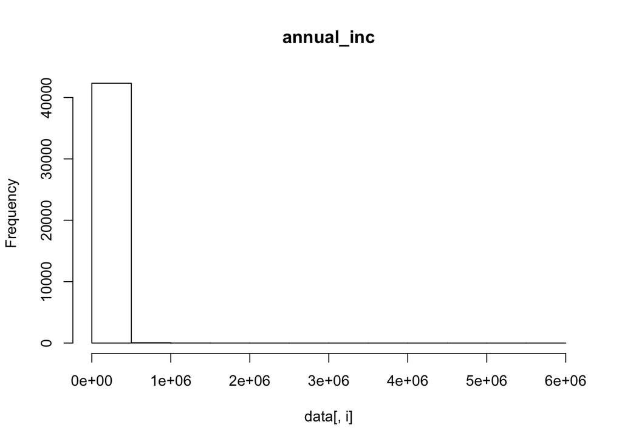

```
## [1] "hist(data[,11],main=\"annual_inc\")"
```

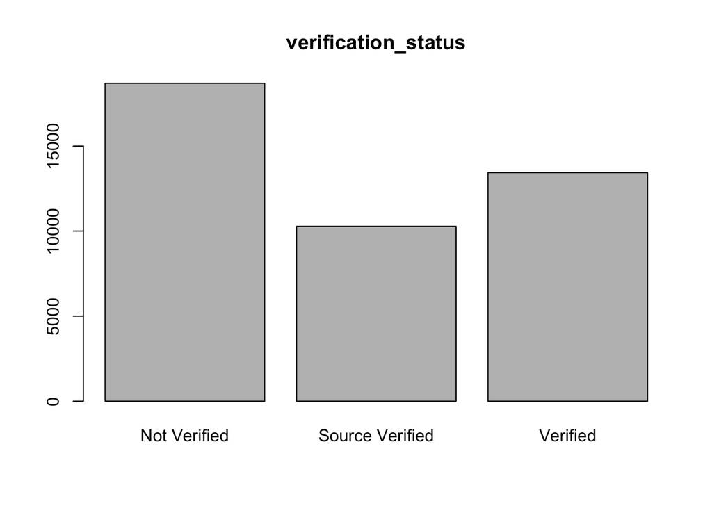

```
## [1] "freq(data[,12],main=\"verification_status\")"
```

[19 more figures not shown]

```
## [1] "hist(data[,31],main=\"mths_sincedelinq\")"
```

```r
for(i in 1:ncol(data)){
  if(is.factor(data[,i])){
    freq(data[,i],main=colnames(data)[i])
    print(paste("freq(data[,",i,"],main=\"",colnames(data)[i],'")',sep=""))
  }else{

    hist(data[,i],main=colnames(data)[i])
    print(paste("hist(data[,",i,"],main=\"",colnames(data)[i],'")',sep=""))
  }
}
```

## Machine Learning

I created an ‘id’ sample from the total ‘N’ observations with 70% of that data, totalling 29,684 loans. From here, I set the training data to consitute this newly created sample and utilized the remaining 30% as the test set.

```r
id<-sample(1:N,0.7*N)
length(id)
```

```
## [1] 29684
```

```r
d_train<-data[id,]
d_test<-data[-id,]

library(descr)
library(ggplot2)
library(ggplot2)
library(randomForest)
dim(d_train)
```

```
## [1] 29684    31
```

```r
dim(d_test)
```

```
## [1] 12722    31
```

### Modeling

#### Random Forests

```r
rf <- randomForest(loan_status ~ ., data = d_train, ntree = 500)
rf
```

```
##
## Call:
##  randomForest(formula = loan_status ~ ., data = d_train, ntree = 500)
##                Type of random forest: classification
##                      Number of trees: 500
## No. of variables tried at each split: 5
##
##         OOB estimate of  error rate: 32.57%
## Confusion matrix:
##             Charged Off Fully Paid class.error
## Charged Off        2618       1819   0.4099617
## Fully Paid         7848      17399   0.3108488
```

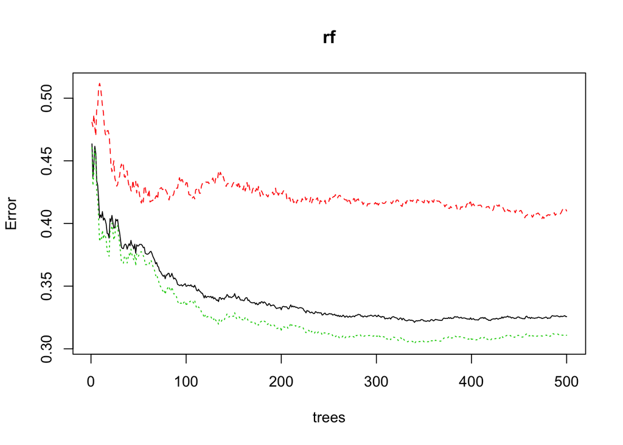

```r
plot(rf)
```